# XGBoost - Multiclasificacion

Alejandro Bedoya Cataño

30/3/2021

# Carga de paquetes

```r
library("xgboost")
library("caret")
library("dplyr")
library("e1071")
library("Ckmeans.1d.dp")
```

# Lectura de las bases de datos

```r
setwd("C:/Users/123/Desktop/TAE/Actividades/TRABAJO 1")
train <- read.csv("train.csv", header = TRUE)
test <- read.csv("test.csv", header = TRUE)
train <- train[,-c(1)]
test <- test[,-c(1)]
summary(train$Hijos) #El algoritmo precisa que se empiece en 0
```

```
##    Min. 1st Qu.  Median    Mean 3rd Qu.    Max.
##   0.000   0.000   1.000   1.119   2.000  11.000
```

# Creación de matrices xgb

Primero la partición de respuesta y covariables para cada base en matrices y vectores.

```r
train_label  <- train[,"Hijos"]
test_label <- test[,"Hijos"]
train_covariables <- as.matrix(train[,-1])
test_covariables <- as.matrix(test[,-1])
```

Ahora la creación de las matrices de entrenamiento y prueba

```r
train_matrix <- xgb.DMatrix(data = train_covariables, label = train_label)
test_matrix <- xgb.DMatrix(data = test_covariables, label = test_label)
```

# Validación cruzada en k-folds para estimar el error

```r
numero_de_clases <- length(unique(train$Hijos))
parametros_xgb <- list("objective"="multi:softprob",
                       "eval_metric"="mlogloss",
                       "num_class"=numero_de_clases)
nrondas <- 50  #Número máximo de rondas a ejecutar en el boosteo
nfolds_cv <- 5

# Ajusta cv.nfold * cv.nround XGB models and save OOF predictions
modelo_cv <- xgb.cv(params = parametros_xgb,
                   data = train_matrix,
                   nrounds = nrondas,
                   nfold = nfolds_cv,
                   verbose = FALSE,
                   prediction = TRUE)
```

# Error de las predicciones usando una muestra Out of Fold (OOF)

La muestra out of fold es una sub-muestra que se hace en el procedimiento y que no se incluye para el entrenamiento funcionando, a pequeña escala, como otro test-set que da una idea de cómo se está comportando el modelo antes de que lo tanteemos en el test set definitivo.

```r
prediccion_OOF <- data.frame(modelo_cv$pred) %>%
  mutate(max_prob = max.col(., ties.method = "last"),
         label = train_label+1)
head(prediccion_OOF)
```

```
##            X1           X2           X3           X4           X5           X6
## 1 0.015065049 1.234618e-01 3.754240e-01 2.959927e-01 1.621895e-01 1.946088e-02
## 2 0.995877504 4.040733e-03 1.892232e-05 1.281593e-05 6.769757e-06 6.315068e-06
## 3 0.086260222 2.977699e-01 6.155853e-01 8.474077e-05 4.125236e-05 3.844204e-05
## 4 0.999910474 7.248748e-05 5.162522e-06 2.525532e-06 1.412221e-06 1.173235e-06
## 5 0.232601732 7.667322e-01 2.196191e-04 1.203666e-04 4.621180e-05 4.160794e-05
## 6 0.005775007 4.400000e-02 2.661013e-01 6.790717e-01 4.739796e-03 4.543862e-05
##             X7           X8           X9          X10          X11          X12
## 1 5.230770e-03 8.729423e-04 2.117356e-03 6.241204e-05 6.189199e-05 6.074643e-05
## 2 6.139376e-06 6.029438e-06 6.035162e-06 6.002714e-06 5.917326e-06 6.785697e-06
## 3 3.738997e-05 3.665311e-05 3.673969e-05 3.642939e-05 3.656140e-05 3.640119e-05
## 4 1.141127e-06 1.118637e-06 1.121279e-06 1.111809e-06 1.115839e-06 1.110948e-06
## 5 4.046923e-05 3.967169e-05 3.976540e-05 3.942953e-05 3.957242e-05 3.939901e-05
## 6 4.417459e-05 5.023849e-05 4.343464e-05 4.323223e-05 4.258536e-05 4.305222e-05
##   max_prob label
## 1        3     6
## 2        1     1
## 3        3     1
## 4        1     1
## 5        2     2
## 6        4     4
```

# Matriz de confusión para la predicción con OOF

```r
confusionMatrix(factor(prediccion_OOF$max_prob),
                factor(prediccion_OOF$label),
                mode = "everything")
```

```
## Confusion Matrix and Statistics
##
##           Reference
## Prediction     1     2     3     4     5     6     7     8     9    10    11
##         1  22017   600    79    12     2     0     1     0     0     0     0
##         2   2993 14936  1472   345    64    12     1     0     0     0     0
##         3    470  2145 10243   545   182    37     4     0     1     0     0
##         4     86   438  1286  3836   199    72    23     7     1     0     0
##         5     22   102   258   442  1153    90    21     5     3     0     0
##         6      7    11    57   108   130   311    26    13     3     1     0
##         7      1     4    11    22    27    54   117    10     4     0     1
##         8      1     0     1     4     3    11    14    26     9     1     1
##         9      0     0     0     0     0     0     4     3     5     1     0
##         10     0     1     0     0     0     0     1     0     0     0     0
##         11     0     0     0     2     0     0     0     0     0     0     0
##         12     0     0     0     0     0     0     0     0     0     0     0
##           Reference
## Prediction    12
##         1      0
##         2      0
##         3      0
##         4      0
##         5      1
##         6      0
##         7      1
##         8      0
##         9      0
##         10     0
##         11     0
##         12     0
##
## Overall Statistics
##
##                Accuracy : 0.8073
##                  95% CI : (0.8042, 0.8103)
##     No Information Rate : 0.3925
##     P-Value [Acc > NIR] : < 2.2e-16
##
##                   Kappa : 0.7349
##
```

[output cut: 13 more lines]

```
## Detection Rate         0.3376   0.2290   0.1571  0.05882  0.01768 0.004769
## Detection Prevalence   0.3483   0.3040   0.2090  0.09121  0.03216 0.010228
## Balanced Accuracy      0.9213   0.8575   0.8493  0.84317  0.82012 0.762152
##                      Class: 7  Class: 8  Class: 9 Class: 10 Class: 11 Class: 12
## Sensitivity          0.551887 0.4062500 1.923e-01 0.000e+00 0.000e+00 0.000e+00
## Specificity          0.997923 0.9993093 9.999e-01 1.000e+00 1.000e+00 1.000e+00
## Pos Pred Value       0.464286 0.3661972 3.846e-01 0.000e+00 0.000e+00       NaN
## Neg Pred Value       0.998538 0.9994167 9.997e-01 1.000e+00 1.000e+00 1.000e+00
## Precision            0.464286 0.3661972 3.846e-01 0.000e+00 0.000e+00        NA
## Recall               0.551887 0.4062500 1.923e-01 0.000e+00 0.000e+00 0.000e+00
## F1                   0.504310 0.3851852 2.564e-01       NaN       NaN        NA
## Prevalence           0.003251 0.0009814 3.987e-04 4.600e-05 3.067e-05 3.067e-05
## Detection Rate       0.001794 0.0003987 7.667e-05 0.000e+00 0.000e+00 0.000e+00
## Detection Prevalence 0.003864 0.0010887 1.993e-04 3.067e-05 3.067e-05 0.000e+00
## Balanced Accuracy    0.774905 0.7027796 5.961e-01 5.000e-01 5.000e-01 5.000e-01
```

Obsérven que hay buenos valores para los apartados de sensitivity, specificity y en general para precisión, sobre todo al predecir números de hijos no muy grandes. Para los valores más extremos se observa un decaimiento notorio en la precisión. Con esto en mente y viendo el aparente buen desempeño al usar los datos OOF, veamos qué tal se da el desempeño en nuestra base de test

# Entrenamiento del modelo y evaluación del desempeño en datos de prueba

Primero se entrena el modelo con los parámetros predefinidos arriba

```r
parametros_xgb <- list("objective"="multi:softprob",
                       "eval_metric"="mlogloss",
                       "num_class"=numero_de_clases,
                       eta = 0.3,
                       early_stoppin_rounds = 200,
                       nfold =10, nrounds = 1000,
                       max_depth = 6)   #Se puede hacer hyperparameter tunning
modelo_xg <- xgb.train(params = parametros_xgb,
                       data = train_matrix,
                       nrounds = nrondas)
```

[output not shown]

Ahora se hace la predicción para el conjunto de prueba

```r
# Predict para el test set
test_pred <- predict(modelo_xg, newdata = test_matrix)
test_prediction <- matrix(test_pred, nrow = numero_de_clases,
                          ncol=length(test_pred)/numero_de_clases) %>%
  t() %>%
  data.frame() %>%
  mutate(label = test_label+1,
         max_prob = max.col(., "last"))
# Matriz de confusión para el test set
confusionMatrix(factor(test_prediction$max_prob),
                factor(test_prediction$label),
                mode = "everything")
```

```
## Confusion Matrix and Statistics
##
##           Reference
## Prediction    1    2    3    4    5    6    7    8    9   10   11
##         1  9455  281   29    3    0    0    0    0    0    0    0
##         2  1300 6368  622  165   31    2    0    0    0    0    0
##         3   217  920 4434  216   70   13    2    1    0    0    0
##         4    32  158  522 1680  103   31    6    3    1    0    0
##         5    15   26  111  179  481   30    9    2    4    1    1
##         6     1    9   20   42   45  151   12    4    0    0    0
##         7     1    2    5   10   15   22   40    2    0    0    0
##         8     0    0    1    3    1    4    3   19    0    1    0
##         9     0    0    1    0    0    1    2    0    5    0    0
##         10    0    1    0    0    0    0    0    0    0    0    0
##         11    0    0    0    0    0    0    0    0    0    0    0
##
## Overall Statistics
##
##                Accuracy : 0.8099
##                  95% CI : (0.8052, 0.8144)
##     No Information Rate : 0.3944
##     P-Value [Acc > NIR] : < 2.2e-16
##
##                   Kappa : 0.7382
##
##  Mcnemar's Test P-Value : NA
##
## Statistics by Class:
##
##                      Class: 1 Class: 2 Class: 3 Class: 4 Class: 5 Class: 6
## Sensitivity            0.8579   0.8201   0.7718  0.73107  0.64477 0.594488
## Specificity            0.9815   0.8950   0.9352  0.96663  0.98610 0.995197
## Pos Pred Value         0.9680   0.7502   0.7550  0.66246  0.55995 0.531690
## Neg Pred Value         0.9139   0.9282   0.9406  0.97568  0.99022 0.996277
## Precision              0.9680   0.7502   0.7550  0.66246  0.55995 0.531690
## Recall                 0.8579   0.8201   0.7718  0.73107  0.64477 0.594488
## F1                     0.9096   0.7836   0.7633  0.69508  0.59938 0.561338
## Prevalence             0.3944   0.2778   0.2056  0.08223  0.02669 0.009089
## Detection Rate         0.3383   0.2279   0.1587  0.06011  0.01721 0.005403
## Detection Prevalence   0.3495   0.3037   0.2101  0.09074  0.03074 0.010162
## Balanced Accuracy      0.9197   0.8575   0.8535  0.84885  0.81544 0.794843
##                      Class: 7  Class: 8  Class: 9 Class: 10 Class: 11
## Sensitivity          0.540541 0.6129032 0.5000000 0.000e+00 0.000e+00
## Specificity          0.997955 0.9995343 0.9998568 1.000e+00 1.000e+00
## Pos Pred Value       0.412371 0.5937500 0.5555556 0.000e+00       NaN
## Neg Pred Value       0.998779 0.9995701 0.9998210 9.999e-01 1.000e+00
## Precision            0.412371 0.5937500 0.5555556 0.000e+00        NA
## Recall               0.540541 0.6129032 0.5000000 0.000e+00 0.000e+00
## F1                   0.467836 0.6031746 0.5263158       NaN        NA
## Prevalence           0.002648 0.0011092 0.0003578 7.156e-05 3.578e-05
## Detection Rate       0.001431 0.0006799 0.0001789 0.000e+00 0.000e+00
## Detection Prevalence 0.003471 0.0011450 0.0003220 3.578e-05 0.000e+00
## Balanced Accuracy    0.769248 0.8062188 0.7499284 5.000e-01 5.000e-01
```

# Importancia de las variables

```r
# Nombres de las variables
nombres <-  colnames(train[,-1])
# Muestra la matriz de importancia de las variables
matriz_de_importancia = xgb.importance(feature_names = nombres, model = modelo_xg)
head(matriz_de_importancia)
```

```
##                Feature       Gain       Cover  Frequency
## 1: CANT_PERSONAS_HOGAR 0.64805178 0.280137305 0.10717712
## 2:      conyugue_hogar 0.17646084 0.037455189 0.03749891
## 3:       edad_conyugue 0.05389819 0.109530493 0.11642103
## 4:           edad_jefe 0.03049171 0.100203128 0.12208947
## 5:                sexo 0.02522406 0.007750028 0.02223773
## 6:             I_HOGAR 0.01322186 0.082657207 0.12801953
```

Gráfico para la importancia de las variables y su aporte a la clasificación del modelo

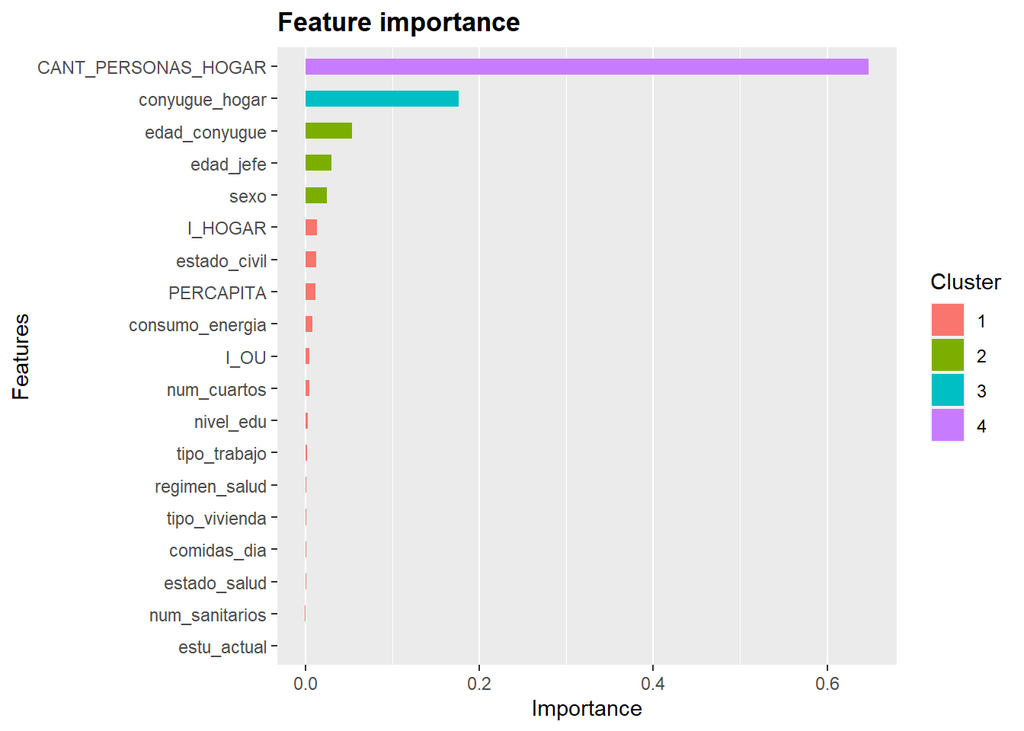

```r
P1 <- xgb.ggplot.importance(matriz_de_importancia)
print(P1)
```